# Timing all gains on chromosome 8 - Timing events across chromosome arm to check consistency

# Looking only at WGD events

Subset for WGD event samples only

```r
timing_results_wgd <- timing_results_sub[grepl("W",timing_results_sub$event_order),]
```

Melt data

```r
timing_results_wgd_melt <- melt(as.data.table(timing_results_wgd),
                                     id.vars = c("sample","region","highest_copy_number",
                                                 "event_order","num_mutations_used",
                                                 "start","end"),
                                     measure.vars = c("t_1_mean_bootstrap","t_2_mean_bootstrap",
                                                      "t_3_mean_bootstrap","t_4_mean_bootstrap",
                                                      "t_5_mean_bootstrap","t_6_mean_bootstrap",
                                                      "t_7_mean_bootstrap","t_8_mean_bootstrap",
                                                      "t_9_mean_bootstrap"))
```

Create an event symbol column for each timepoint to indicate whether it is a W or G

```r
timing_results_wgd_melt$event_symbol <- ifelse(timing_results_wgd_melt$variable == "t_1_mean_bootstrap",
                                                    yes = substr(timing_results_wgd_melt$event_order,1,1),
                                                    no = ifelse(timing_results_wgd_melt$variable == "t_2_mean_bootstrap",
                                                                yes = substr(timing_results_wgd_melt$event_order,2,2),
                                                                no = ifelse(timing_results_wgd_melt$variable == "t_3_mean_bootstrap",
                                                                            yes = substr(timing_results_wgd_melt$event_order,3,3),
                                                                            no = ifelse(timing_results_wgd_melt$variable == "t_4_mean_bootstrap",
                                                                                        yes = substr(timing_results_wgd_melt$event_order,4,4),
                                                                                        no = ifelse(timing_results_wgd_melt$variable == "t_5_mean_bootstrap",
                                                                                                    yes = substr(timing_results_wgd_melt$event_order,5,5),
                                                                                                    no = ifelse(timing_results_wgd_melt$variable == "t_6_mean_bootstrap",
                                                                                                                yes = substr(timing_results_wgd_melt$event_order,6,6),
                                                                                                                no = ifelse(timing_results_wgd_melt$variable == "t_7_mean_bootstrap",
                                                                                                                            yes = substr(timing_results_wgd_melt$event_order,7,7),
                                                                                                                            no = ifelse(timing_results_wgd_melt$variable == "t_8_mean_bootstrap",
                                                                                                                                        yes = substr(timing_results_wgd_melt$event_order,8,8),
                                                                                                                                        no = ifelse(timing_results_wgd_melt$variable == "t_9_mean_bootstrap",
                                                                                                                                                    yes = substr(timing_results_wgd_melt$event_order,9,9),
                                                                                                                                                    no = NA)))))))))
```

```r
timing_results_wgd_melt$event_symbol_number <- paste0(timing_results_wgd_melt$event_symbol,
                                                           substr(timing_results_wgd_melt$variable,3,3))
```

Remove unused timepoints (e.g. remove t_7 NA values from samples that only had 6 timepoints)

```r
timing_results_wgd_melt <- timing_results_wgd_melt[!is.na(timing_results_wgd_melt$value)]
```

Select the WGD times

```r
timing_results_wgd_melt_w <- subset(timing_results_wgd_melt, event_symbol == "W")
```

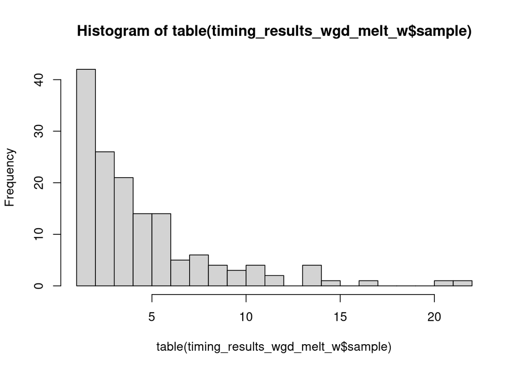

```r
hist(table(timing_results_wgd_melt_w$sample),breaks = 20)
```

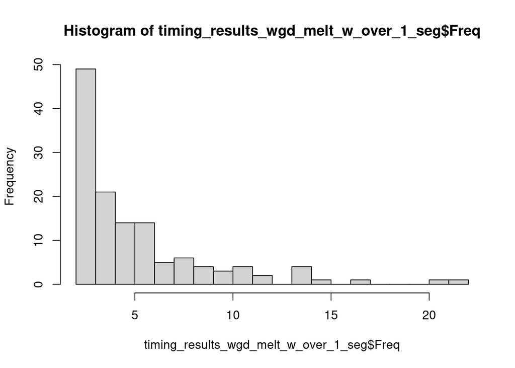

```r
timing_results_wgd_melt_w_over_1_seg <- as.data.frame(table(timing_results_wgd_melt_w$sample))
timing_results_wgd_melt_w_over_1_seg <- subset(timing_results_wgd_melt_w_over_1_seg, Freq > 1)
hist(timing_results_wgd_melt_w_over_1_seg$Freq,breaks = 20)
```

Summary of number of timed segments per sample for samples with >1 timed WGD segment.

```r
summary(timing_results_wgd_melt_w_over_1_seg)
```

```
##                                    Var1          Freq
##  0009b464-b376-4fbc-8a56-da538269a02f:  1   Min.   : 2.000
##  01658141-8398-4585-9f0f-8355dd9b0604:  1   1st Qu.: 3.000
##  01df36af-3617-40fc-9892-f54ce433cf71:  1   Median : 4.000
##  052665d1-ab75-4f40-be5a-b88154c8beed:  1   Mean   : 5.462
##  09508a0d-ebe0-4fa1-b7b2-1710814181cd:  1   3rd Qu.: 6.000
##  123c9d1c-72ba-4d82-8e57-d5caa52a40ba:  1   Max.   :22.000
##  (Other)                             :124
```

Mean ~5 segments along chromosome 8 for WGD samples that have more than one WGD segment estimate across the chromosome.

Create output tables for coefficient of variation

```r
cov_wgd_time_output <- as.data.frame(matrix(nrow = nrow(timing_results_wgd_melt_w_over_1_seg), ncol = 4))
colnames(cov_wgd_time_output) <- c("sample","coefficient_of_variation","average_num_mutations_used","num_segments")
cov_wgd_time_output$sample <- timing_results_wgd_melt_w_over_1_seg$Var1

cov_wgd_time_output_random <- as.data.frame(matrix(nrow = nrow(timing_results_wgd_melt_w_over_1_seg), ncol = 4))
colnames(cov_wgd_time_output_random) <- c("sample","coefficient_of_variation","average_num_mutations_used","num_segments")
cov_wgd_time_output_random$sample <- paste0("sample_",1:nrow(timing_results_wgd_melt_w_over_1_seg))
```

Calculate the coefficient of variation for WGD estimates within each sample.

```r
for(i in 1:nrow(cov_wgd_time_output)){
  sub_wgd_melt <- subset(timing_results_wgd_melt, sample == cov_wgd_time_output$sample[i] &
                           event_symbol == "W")

  sample_sd <- sd(sub_wgd_melt$value)
  sample_mean <- mean(sub_wgd_melt$value)
  sample_cov <- (sample_sd/sample_mean)

  mean_muts <- mean(sub_wgd_melt$num_mutations_used)

  cov_wgd_time_output$coefficient_of_variation[i] <- sample_cov
  cov_wgd_time_output$average_num_mutations_used[i] <- mean_muts
  cov_wgd_time_output$num_segments[i] <- nrow(sub_wgd_melt)
}
cov_wgd_time_output$type <- "Within Sample"
```

Assign NaN to 0; these are samples with an estimate of timepoint = 0 across all samples, so mean is 0 (which we can't divide by).

```r
cov_wgd_time_output$coefficient_of_variation[is.nan(cov_wgd_time_output$coefficient_of_variation)] <- 0
```

Add outlier column for ease of plotting

```r
cov_wgd_time_output$outlier <- ifelse(test = cov_wgd_time_output$coefficient_of_variation > (quantile(cov_wgd_time_output$coefficient_of_variation, 0.75)+(1.50*IQR(cov_wgd_time_output$coefficient_of_variation))), yes = "Outlier", no = ifelse(test = cov_wgd_time_output$coefficient_of_variation < (quantile(cov_wgd_time_output$coefficient_of_variation, 0.25)-(1.50*IQR(cov_wgd_time_output$coefficient_of_variation))), yes = "Outlier", no = NA))
```

From the pool of timed samples, randomly select n WGD times (distribution og n is equal that of real data) and calculate coefficient of variation.

```r
for(i in 1:nrow(cov_wgd_time_output_random)){
  sub_wgd_melt <- subset(timing_results_wgd_melt, event_symbol == "W" &
                           sample %in% timing_results_wgd_melt_w_over_1_seg$Var1)

  n_wgd_segments_to_sample <- cov_wgd_time_output$num_segments[i] # try using the number of samples used in real data rather than just mean

  sub_wgd_melt <- sub_wgd_melt[(sample(1:nrow(sub_wgd_melt), size = n_wgd_segments_to_sample, replace = FALSE)),]

  sample_sd <- sd(sub_wgd_melt$value)
  sample_mean <- mean(sub_wgd_melt$value)
  sample_cov <- (sample_sd/sample_mean)

  mean_muts <- mean(sub_wgd_melt$num_mutations_used)

  cov_wgd_time_output_random$coefficient_of_variation[i] <- sample_cov
  cov_wgd_time_output_random$average_num_mutations_used[i] <- mean_muts
  cov_wgd_time_output_random$num_segments[i] <- nrow(sub_wgd_melt)
}
cov_wgd_time_output_random$type <- "Randomly Sampled"
```

Assign NaN to 0; these are samples with an estimate of timepoint 0 across all samples, so mean is 0 (which we can't divide by).

```r
cov_wgd_time_output_random$coefficient_of_variation[is.nan(cov_wgd_time_output_random$coefficient_of_variation)] <- 0
```

Add outlier column for ease of plotting

```r
cov_wgd_time_output_random$outlier <- ifelse(test = cov_wgd_time_output_random$coefficient_of_variation > (quantile(cov_wgd_time_output_random$coefficient_of_variation, 0.75)+(1.50*IQR(cov_wgd_time_output_random$coefficient_of_variation))), yes = "Outlier", no = ifelse(test = cov_wgd_time_output_random$coefficient_of_variation < (quantile(cov_wgd_time_output_random$coefficient_of_variation, 0.25)-(1.50*IQR(cov_wgd_time_output_random$coefficient_of_variation))), yes = "Outlier", no = NA))
```

Combine real and random coefficients of variation and compare

```r
cov_combined <- rbind(cov_wgd_time_output, cov_wgd_time_output_random)
```

Check if there is a significant difference between them.

```r
wilcox.test(cov_wgd_time_output$coefficient_of_variation, cov_wgd_time_output_random$coefficient_of_variation)
```

```
##
##  Wilcoxon rank sum test with continuity correction
##
## data:  cov_wgd_time_output$coefficient_of_variation and cov_wgd_time_output_random$coefficient_of_variation
## W = 6914, p-value = 0.01132
## alternative hypothesis: true location shift is not equal to 0
```

# Plot COV

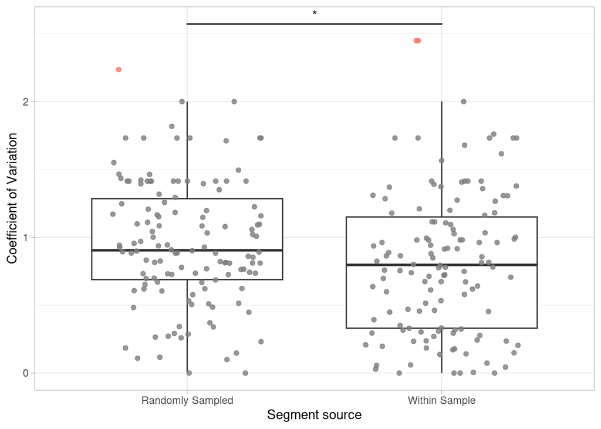

```r
cov_plot <- ggplot(cov_combined, aes(y = coefficient_of_variation, x = type))+
  geom_boxplot(outlier.colour = NA)+
  geom_jitter(alpha = 0.8, width = 0.3, aes(colour = outlier))+
  ylab("Coefficient of Variation")+
  xlab("Segment source")+
  theme_light()+
  theme(legend.position = "none")+
  geom_signif(map_signif_level = TRUE, tip_length = 0, comparisons = list(c("Randomly Sampled","Within Sample")),
              method = "wilcox")
cov_plot
```

# Save plot

```r
png(paste0(outdir,"cov_c8_wgd_",Sys.Date(),".png"),
    res = resolution, height = 12, width = figure_width, units = "cm")
cov_plot
dev.off()
```

Save session info

```r
writeLines(capture.output(sessionInfo()), paste0(outdir,"plotting_cov_c8_sessionInfo_",Sys.Date(),".txt"))
```